# GIS_FINAL

Brandt Jackson

March 8, 2020

## Brandt Jackson - GIS Final

### Read in libraries

```r
# Module 5: Point Pattern Analysis Using R, Part 1

library(GISTools)
library(raster)
library(spatstat)
library(ggmap)
library(jsonlite)
library(gapminder)
library(GISTools)
library(sf)
library(dplyr)
library(rgdal)
library(tmap)
require(deldir)
```

```r
require(sp)

library(ggmap)


#library(sf)
library(dplyr)
library(spDataLarge)
library(stplanr)      # geographic transport data package
#library(tmap)         # visualization package (see Chapter 8)
library(osmdata)
```

## Read in Bristol Region OSM Data - SF Polygon Object

```r
bristol_region = osmdata::getbb("Bristol", format_out = "sf_polygon")
```

[output not shown]

## View Names of Bristol Zones - “geo_code”, “name” and “geometry”

```r
names(bristol_zones)
```

```
## [1] "geo_code" "name"     "geometry"
```

```r
summary(bristol_od)
```

```
##       o                  d                  all             bicycle
##  Length:2910        Length:2910        Min.   :  20.00   Min.   :  0.000
##  Class :character   Class :character   1st Qu.:  28.00   1st Qu.:  1.000
##  Mode  :character   Mode  :character   Median :  42.00   Median :  2.000
##                                        Mean   :  82.06   Mean   :  6.216
##                                        3rd Qu.:  82.00   3rd Qu.:  5.000
##                                        Max.   :1493.00   Max.   :311.000
##       foot           car_driver         train
##  Min.   :   0.00   Min.   :  2.00   Min.   : 0.000
##  1st Qu.:   0.00   1st Qu.: 19.00   1st Qu.: 0.000
##  Median :   2.00   Median : 29.00   Median : 0.000
##  Mean   :  16.13   Mean   : 45.47   Mean   : 0.855
##  3rd Qu.:   7.00   3rd Qu.: 51.00   3rd Qu.: 0.000
##  Max.   :1296.00   Max.   :493.00   Max.   :58.000
```

## EDA - View Number of rows for bristol_od and bristol_zones

```r
nrow(bristol_od)
```

```
## [1] 2910
```

```
#> [1] 2910
```

```r
nrow(bristol_zones)
```

```
## [1] 102
```

```
#> [1] 102
```

## ETL - Tranform bristol_od and assign zones_attr

```r
zones_attr = bristol_od %>%
  group_by(o) %>%
  summarize_if(is.numeric, sum) %>%
  dplyr::rename(geo_code = o)
```

## Summarize zones_attr$geo_code

```r
summary(zones_attr$geo_code %in% bristol_zones$geo_code)
```

```
##    Mode    TRUE
## logical     102
```

```
#>    Mode    TRUE
#> logical     102
```

## More ETL - Define zones_joined

```r
zones_joined = left_join(bristol_zones, zones_attr, by = "geo_code")
sum(zones_joined$all)
```

```
## [1] 238805
```

```
#> [1] 238805
```

```r
names(zones_joined)
```

```
## [1] "geo_code"   "name"       "all"        "bicycle"    "foot"
## [6] "car_driver" "train"      "geometry"
```

```
#> [1] "geo_code"   "name"       "all"        "bicycle"    "foot"
#> [6] "car_driver" "train"      "geometry"
```

## Even more ETL - zones_od

```r
zones_od = bristol_od %>%
  group_by(d) %>%
  summarize_if(is.numeric, sum) %>%
  dplyr::select(geo_code = d, all_dest = all) %>%
  inner_join(zones_joined, ., by = "geo_code")
```

## Initial plot of Bristol region, origin and destination

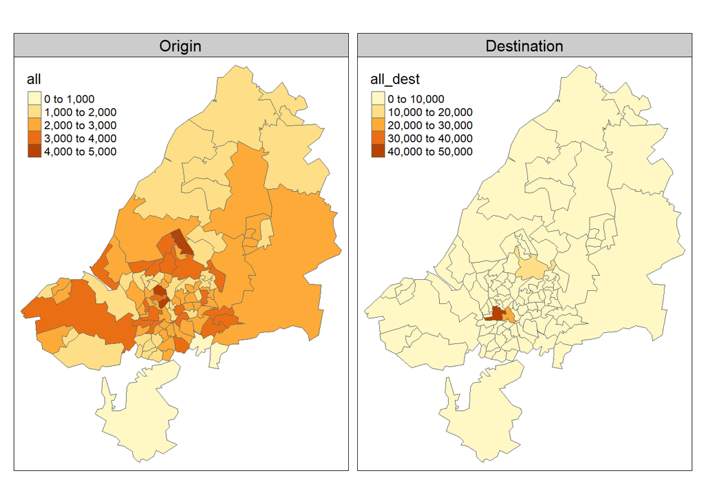

```r
qtm(zones_od, c("all", "all_dest")) +
  tm_layout(panel.labels = c("Origin", "Destination"))
```

```r
od_top5 = bristol_od %>%
  arrange(desc(all)) %>%
  top_n(5, wt = all)
```

## Travel to Work Area (TTWA) for Bristol

```r
bristol_ttwa
```

```
## Simple feature collection with 1 feature and 1 field
## geometry type:  MULTIPOLYGON
## dimension:      XY
## bbox:           xmin: -2.844324 ymin: 51.28248 xmax: -2.252108 ymax: 51.75519
## epsg (SRID):    4326
## proj4string:    +proj=longlat +datum=WGS84 +no_defs
##             Name                       geometry
## 1 Bristol (TTWA) MULTIPOLYGON (((-2.27153 51...
```

## Assigning ACTIVE to both BICYCLE and FOOT routes

```r
bristol_od$Active = (bristol_od$bicycle + bristol_od$foot) /
  bristol_od$all * 100
```

## More ETL

```r
od_intra = filter(bristol_od, o == d)
od_inter = filter(bristol_od, o != d)
```

## Defining the “DESIRE LINES”

## Desire Lines are “Spider Diagrams” that can be either weighted or unweighted based on whether the importance of each route is equal.

## Desire lines will be shown as wider in the charts if they are weighted.

```r
desire_lines = od2line(od_inter, zones_od)
```

```
## Creating centroids representing desire line start and end points.
```

```
#> Creating centroids representing desire line start and end points.
```

## Charting Desire Lines for Bristol

```r
qtm(desire_lines, lines.lwd = "all")
```

```
## Legend labels were too wide. Therefore, legend.text.size has been set to 0.61. Increase legend.width (argument of tm_layout) to make the legend wider and therefore the labels larger.
```

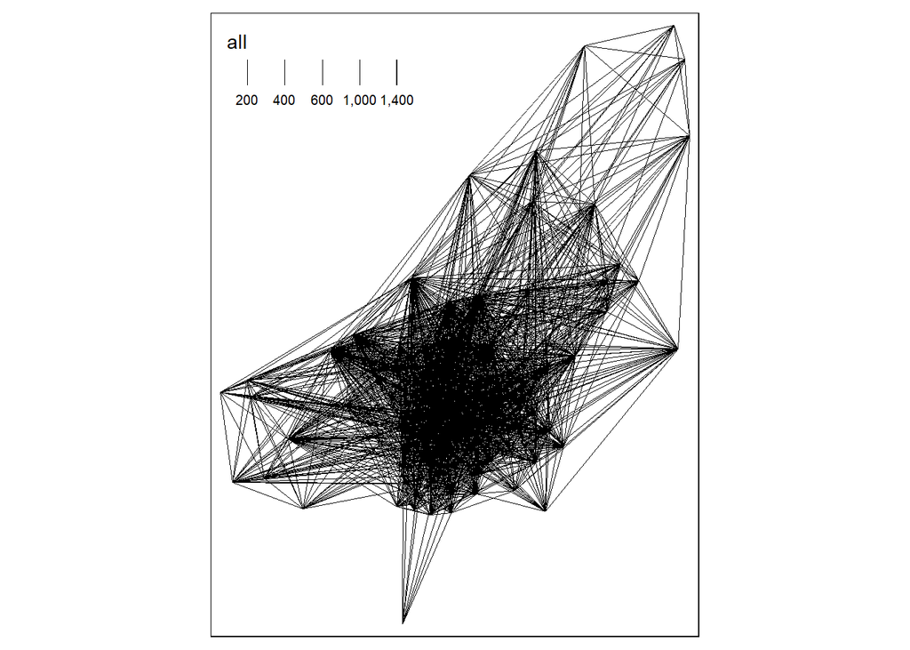

## Calculating Distance of Desire Lines

```r
desire_lines$distance = as.numeric(st_length(desire_lines))
#desire_carshort = dplyr::filter(desire_lines, car_driver > 300 & distance < 5000)
```

```r
#route_osrm
```

```r
#route_carshort = line2route(desire_carshort, route_fun = route_osrm)
```

## Car Path

```r
desire_carshort$geom_car = st_geometry(route_carshort)
```

## Rail Path

```r
desire_rail = top_n(desire_lines, n = 3, wt = train)
```

## Rail Path with Stations

```r
ncol(desire_rail)
```

```
## [1] 10
```

```
#> [1] 10
```

```r
desire_rail = line_via(desire_rail, bristol_stations)
ncol(desire_rail)
```

```
## [1] 13
```

```
#> [1] 13
```

## Summarize the bristol_ways

```r
summary(bristol_ways)
```

```
##      highway        maxspeed         ref                geometry
##  cycleway:1317   30 mph : 925   A38    : 214   LINESTRING   :4915
##  rail    : 832   20 mph : 556   A432   : 146   epsg:4326    :   0
##  road    :2766   40 mph : 397   M5     : 144   +proj=long...:   0
##                  70 mph : 328   A4018  : 124
##                  50 mph : 158   A420   : 115
##                  (Other): 490   (Other):1877
##                  NA's   :2061   NA's   :2295
```

## Freeway routes with weighting analysis

```r
ways_freeway = bristol_ways %>% filter(maxspeed == "70 mph")
ways_sln = SpatialLinesNetwork(ways_freeway)
slotNames(ways_sln)
```

```
## [1] "sl"          "g"           "nb"          "weightfield"
```

```
#> [1] "sl"          "g"           "nb"          "weightfield"
```

```r
weightfield(ways_sln)
```

```
## [1] "length"
```

```
#> [1] "length"
```

```r
class(ways_sln@g)
```

```
## [1] "igraph"
```

```
#> [1] "igraph"
```

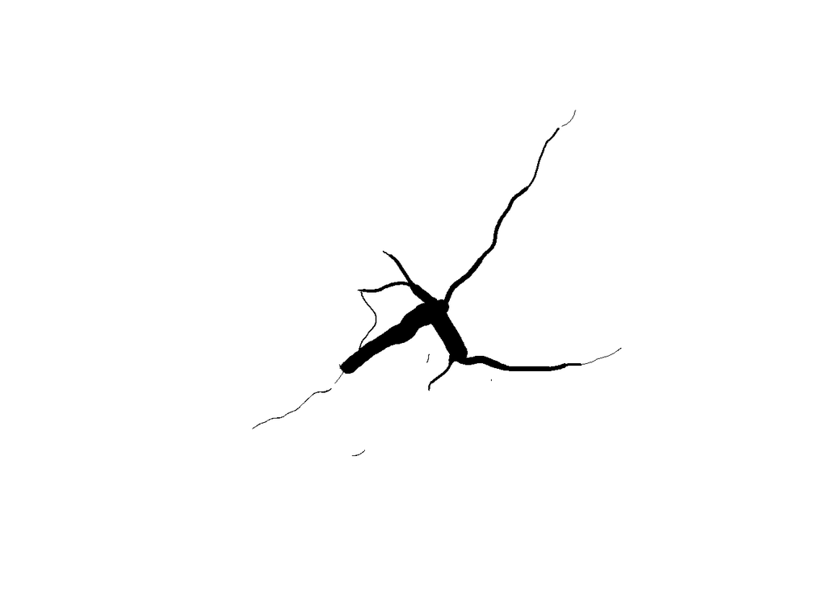

```r
e = igraph::edge_betweenness(ways_sln@g)
plot(ways_sln@sl$geometry, lwd = e / 500)
```

```r
#route_rail = desire_rail %>%
  #st_set_geometry("leg_orig") %>%
  #line2route(route_fun = route_osrm) %>%
  #st_set_crs(4326)
```

```r
route_cycleway = rbind(route_rail, route_carshort)
route_cycleway$all = c(desire_rail$all, desire_carshort$all)
```

```r
summary(route_rail)
```

```
##     distance       duration      error              id
##  Min.   :1639   Min.   :227.7   Mode:logical   Length:3
##  1st Qu.:2494   1st Qu.:307.2   NA's:3         Class :character
##  Median :3349   Median :386.8                  Mode  :character
##  Mean   :2929   Mean   :338.8
##  3rd Qu.:3574   3rd Qu.:394.3
##  Max.   :3798   Max.   :401.8
##           geometry
##  LINESTRING   :3
##  epsg:4326    :0
##  +proj=long...:0
##
##
##
```

```r
summary(route_carshort)
```

```
##     distance        duration      error              id
##  Min.   : 3664   Min.   :389.3   Mode:logical   Length:6
##  1st Qu.: 4230   1st Qu.:475.3   NA's:6         Class :character
##  Median : 4755   Median :511.4                  Mode  :character
##  Mean   : 5535   Mean   :567.1
##  3rd Qu.: 5662   3rd Qu.:581.7
##  Max.   :10017   Max.   :922.0
##           geometry
##  LINESTRING   :6
##  epsg:4326    :0
##  +proj=long...:0
##
##
##
```

```r
summary(route_cycleway)
```

```
##     distance        duration      error              id
##  Min.   : 1639   Min.   :227.7   Mode:logical   Length:9
##  1st Qu.: 3664   1st Qu.:389.3   NA's:9         Class :character
##  Median : 4173   Median :468.2                  Mode  :character
##  Mean   : 4666   Mean   :491.0
##  3rd Qu.: 5107   3rd Qu.:526.2
##  Max.   :10017   Max.   :922.0
##           geometry      all
##  LINESTRING   :9   Min.   :143.0
##  epsg:4326    :0   1st Qu.:221.0
##  +proj=long...:0   Median :569.0
##                    Mean   :459.1
##                    3rd Qu.:628.0
##                    Max.   :669.0
```

## Cycle Routes analysis

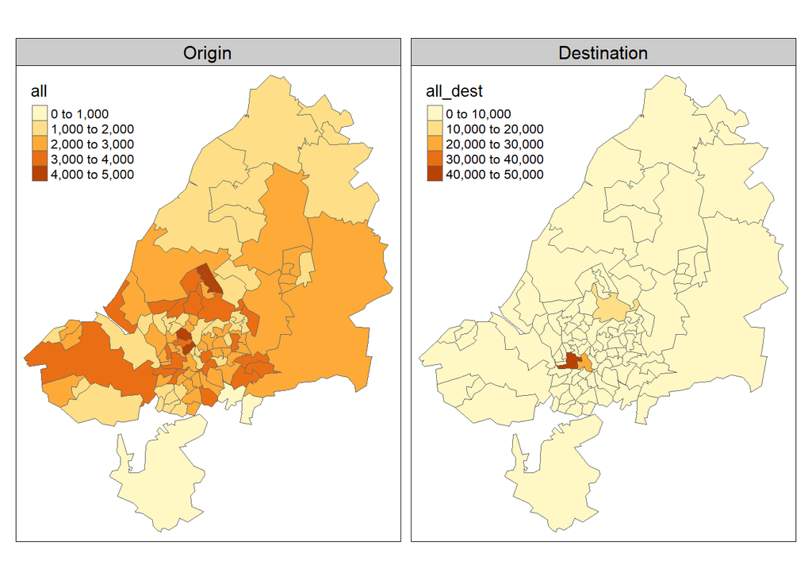

```r
qtm(zones_od, c("all", "all_dest")) +
  tm_layout(panel.labels = c("Origin", "Destination"))
```

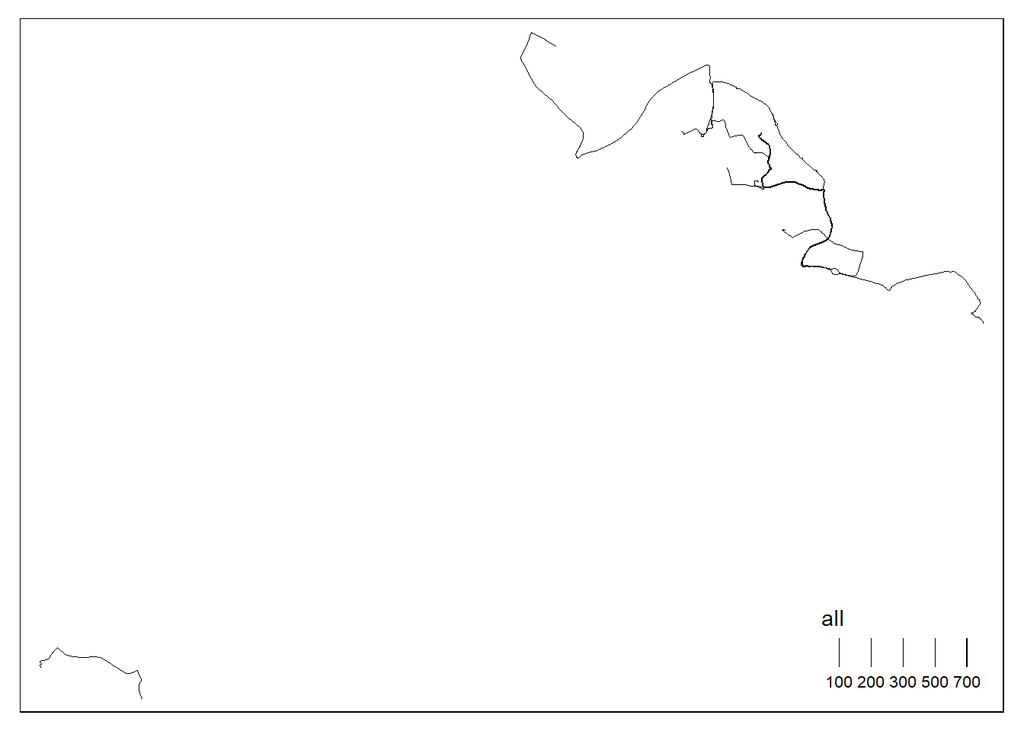

```r
qtm(route_cycleway, lines.lwd = "all")
```

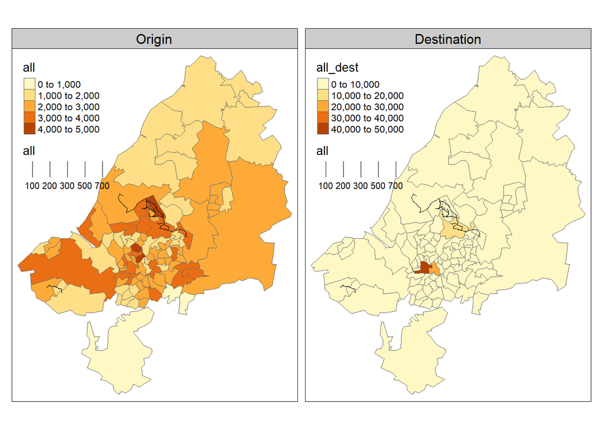

```r
qtm(zones_od, c("all", "all_dest")) +
  tm_layout(panel.labels = c("Origin", "Destination")) + qtm(route_cycleway, lines.lwd = "all")
```

# Question 1

## What is the total distance of cycleways that would be constructed if all the routes presented in Figure 12.6 were to be constructed?

# Answer 1

## Below are two ways of arriving at the same answer, within a small margin. (~42K)

```r
sum(route_cycleway$distance)
```

```
## [1] 41996.8
```

```r
sum(st_length(route_cycleway))
```

```
## 42077.53 [m]
```

```r
#(route_rail, route_carshort)
```

# Question 2

## What proportion of trips represented in the desire_lines are accounted for in the route_cycleway object?

# Answer 2

## About 2% (1.966%) of the trips are accounted for in the route_cycleway object.

```r
sum(route_cycleway$all) / sum(desire_lines$all) # around 2%
```

```
## [1] 0.01966449
```

```r
d_intersect = desire_lines[route_cycleway, , op = st_crosses]
```

```
## although coordinates are longitude/latitude, st_crosses assumes that they are planar
```

```r
sum(d_intersect$all) / sum(desire_lines$all) # around 2%
```

```
## [1] 0.2239524
```

# Question 3

## The analysis presented in this chapter is designed for teaching how geocomputation methods can be applied to transport research. If you were to do this ‘for real’ for local government or a transport consultancy, what top 3 things would you do differently?

# Answer 3

## Higher level of geographic resolution.

## Use cycle-specific routing services.

## Identify key walking routes.

## Include a higher proportion of trips in the analysis

# Question 4

# Answer 4

## I would expand ‘route_cycleway’ to account for more than just ‘route_rail’ and ‘route_carshort’. We could also adjust how carshort is defined to account for a wider scope of distances.

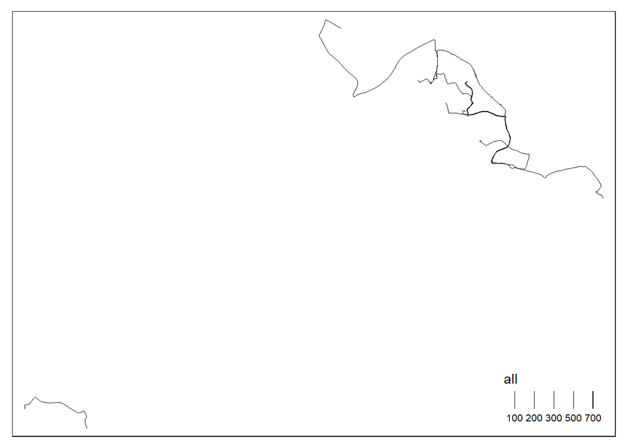

```r
qtm(route_cycleway, lines.lwd = "all")
```

# Question 5

## Imagine that you want to extend the scenario by creating key *areas* (not routes) for investment in place-based cycling policies such as car-free zones, cycle parking points and reduced car parking strategy. How could raster data assist with this work?

# Answer 5

## I would create a raster layer on top of the route_cycle pathway (see below), and do a similar analysis on the area within Bristol that we did with the Kansas City and South Carolina maps, but instead using the areas surrounding the route_cycle pathway (black line)

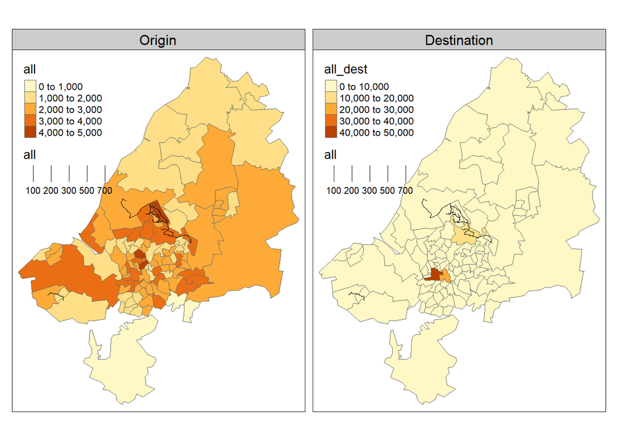

```r
qtm(zones_od, c("all", "all_dest")) +
  tm_layout(panel.labels = c("Origin", "Destination")) + qtm(route_cycleway, lines.lwd = "all")
```